# ASM - Exercise week 6

Tobias Krüger

April 18, 2021

# 5H4

```r
# McElreath page 125
library(rethinking)
data("WaffleDivorce")
d <- WaffleDivorce

# standardize
d$D <- (d$Divorce - mean(d$Divorce))/sd(d$Divorce)
d$M <- (d$Marriage - mean(d$Marriage))/sd(d$Marriage)
d$A <- (d$MedianAgeMarriage - mean(d$MedianAgeMarriage))/sd(d$MedianAgeMarriage)
# except S, which is an indicator variable
# turn this into an index variable (factor)
d$S <- as.factor(d$South)
```

Let’s first look at the possible influence of `S` on `A` and `M`. There are 4 possible DAGs:

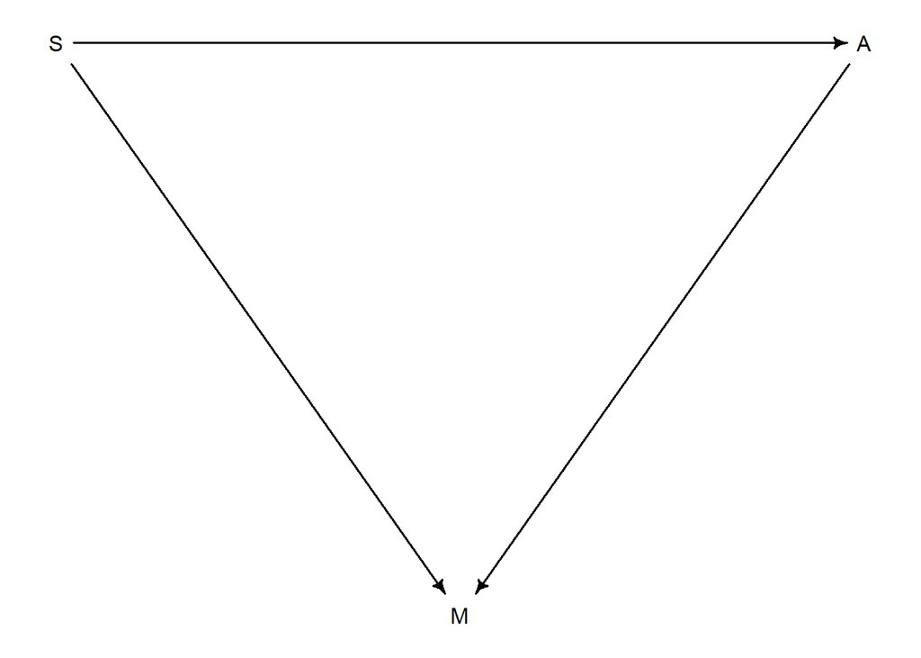

```r
library(dagitty)

dag5H4.1 <- dagitty('dag{ M <- S -> A -> M}')
coordinates(dag5H4.1) <- list(x=c(S=0, M=1, A=2), y=c(S=0, M=1, A=0))
drawdag(dag5H4.1)
```

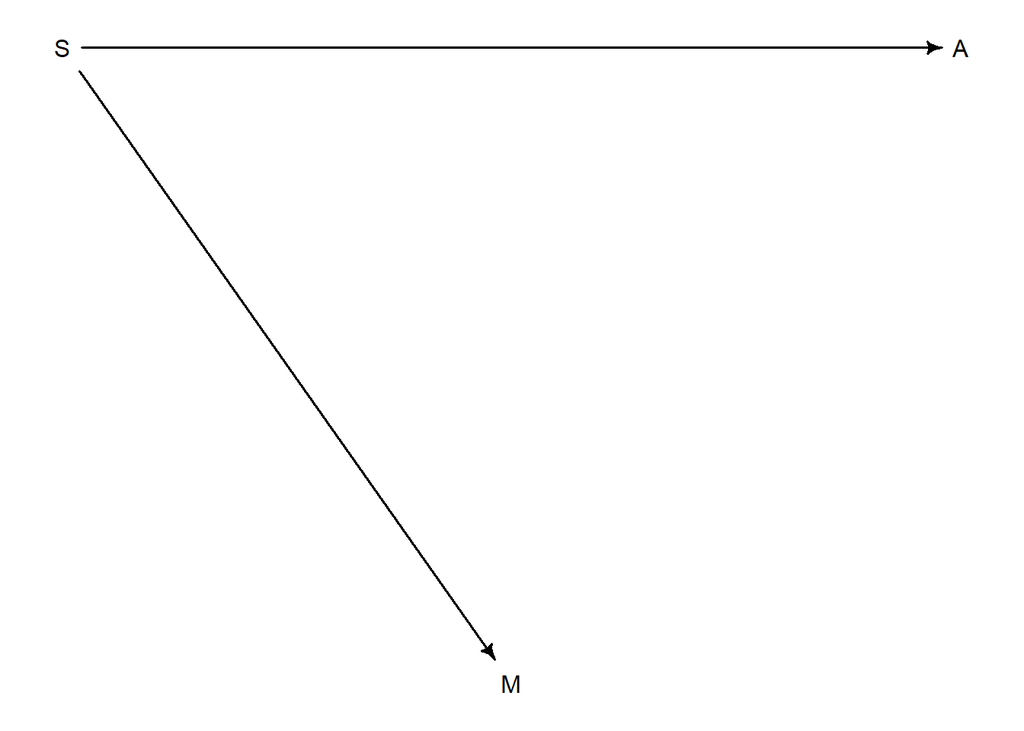

```r
impliedConditionalIndependencies(dag5H4.1)

dag5H4.2 <- dagitty('dag{ M <- S -> A}')
coordinates(dag5H4.2) <- list(x=c(S=0, M=1, A=2), y=c(S=0, M=1, A=0))
drawdag(dag5H4.2)
```

```r
impliedConditionalIndependencies(dag5H4.2)
```

```
## A _||_ M | S
```

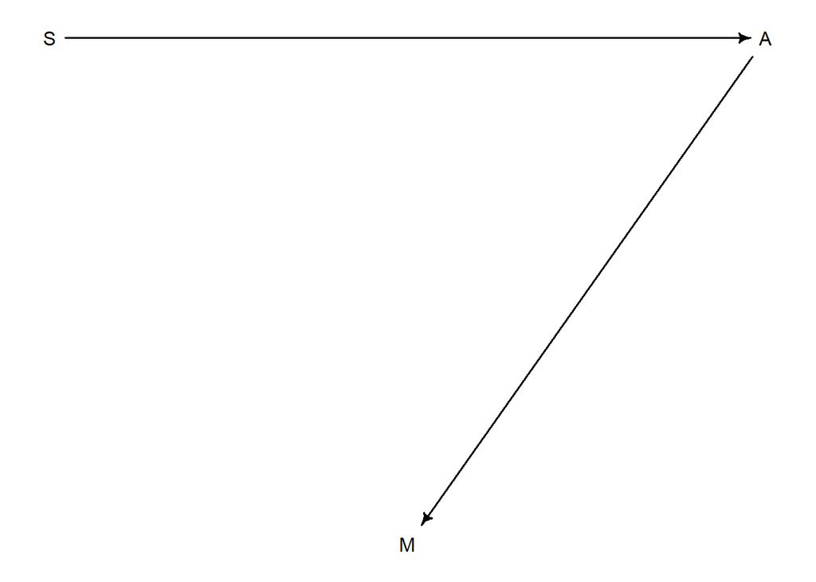

```r
dag5H4.3 <- dagitty('dag{ S -> A -> M}')
coordinates(dag5H4.3) <- list(x=c(S=0, M=1, A=2), y=c(S=0, M=1, A=0))
drawdag(dag5H4.3)
```

```r
impliedConditionalIndependencies(dag5H4.3)
```

```
## M _||_ S | A
```

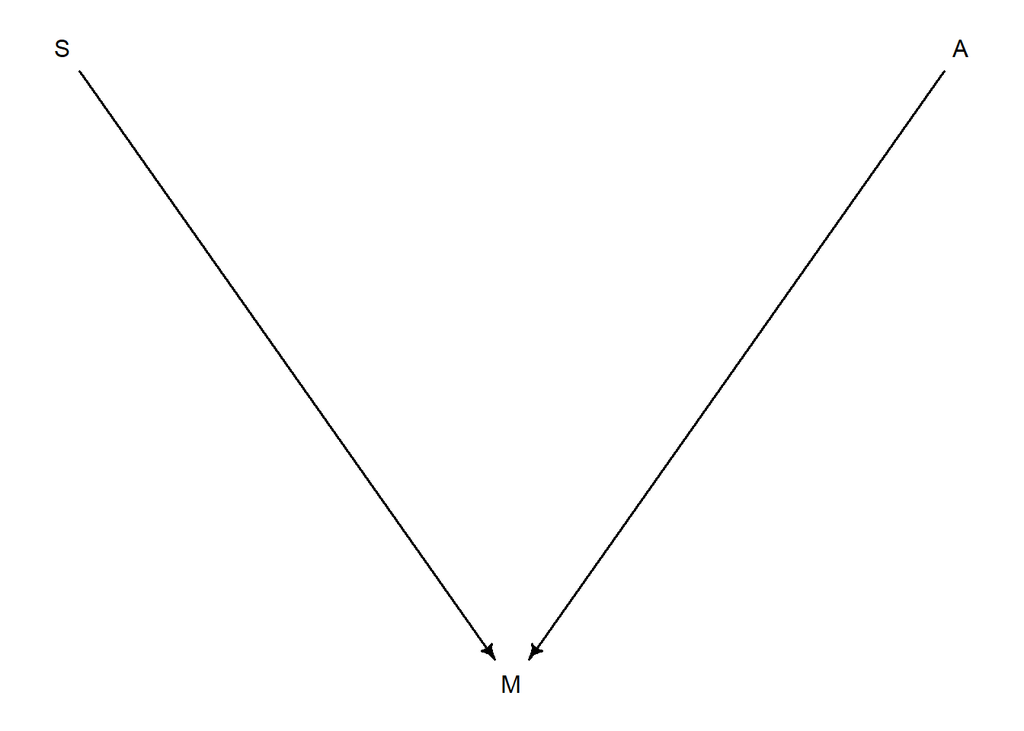

```r
dag5H4.4 <- dagitty('dag{ S -> M <- A}')
coordinates(dag5H4.4) <- list(x=c(S=0, M=1, A=2), y=c(S=0, M=1, A=0))
drawdag(dag5H4.4)
```

```r
impliedConditionalIndependencies(dag5H4.4)
```

```
## A _||_ S
```

The 4th one, `dag5H4.4`, we can test by regressing `A` on `S`:

```r
library(brms)
m1.5H4 <-
  brm(data = d,
      family = gaussian(link = "identity"),
      A ~ 0 + S,
      prior = c(prior(normal(0, 2.5), class = b),
                prior(exponential(1), class = sigma)),
      iter = 5e3
  )
```

```r
summary(m1.5H4)
```

```
##  Family: gaussian
##   Links: mu = identity; sigma = identity
## Formula: A ~ 0 + S
##    Data: d (Number of observations: 50)
## Samples: 4 chains, each with iter = 5000; warmup = 2500; thin = 1;
##          total post-warmup samples = 10000
##
## Population-Level Effects:
##    Estimate Est.Error l-95% CI u-95% CI Rhat Bulk_ESS Tail_ESS
## S0     0.15      0.17    -0.18     0.48 1.00     9984     6873
## S1    -0.39      0.27    -0.92     0.14 1.00    10095     7350
##
## Family Specific Parameters:
##       Estimate Est.Error l-95% CI u-95% CI Rhat Bulk_ESS Tail_ESS
## sigma     0.99      0.10     0.82     1.21 1.00     9667     7155
##
## Samples were drawn using sampling(NUTS). For each parameter, Bulk_ESS
## and Tail_ESS are effective sample size measures, and Rhat is the potential
## scale reduction factor on split chains (at convergence, Rhat = 1).
```

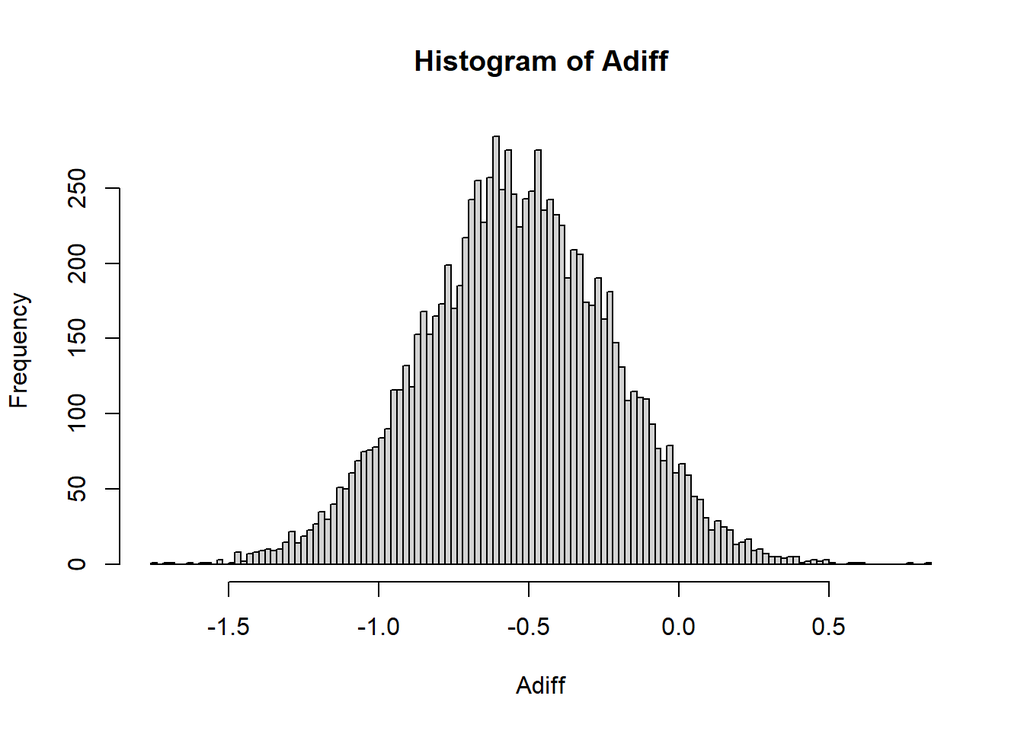

```r
# contrast: difference in A between factor levels of S
A_S0 <- fitted(m1.5H4, newdata = list(S = 0), summary = FALSE)
A_S1 <- fitted(m1.5H4, newdata = list(S = 1), summary = FALSE)
Adiff <- A_S1 - A_S0
hist(Adiff, 100)
```

```r
quantile(Adiff, probs = c(0.025, 0.975))
```

```
##        2.5%       97.5%
## -1.16957388  0.07663652
```

So `A` is not independent from `S` as `dag5H4.4` would suggest, so this can be discarded.

To distinguish `dag5H4.1-3`, we need to compare a regression of `M` on `A` and `S` to both single-predictor cases:

```r
m2.5H4 <-
  brm(data = d,
      family = gaussian(link = "identity"),
      M ~ 1 + A,
      prior = c(prior(normal(0, 2.5), class = Intercept),
                prior(normal(0, 2.5), class = b),
                prior(exponential(1), class = sigma)),
      iter = 5e3
  )

m3.5H4 <-
  brm(data = d,
      family = gaussian(link = "identity"),
      M ~ 0 + S,
      prior = c(prior(normal(0, 2.5), class = b),
                prior(exponential(1), class = sigma)),
      iter = 5e3
  )

m4.5H4 <-
  brm(data = d,
      family = gaussian(link = "identity"),
      M ~ 0 + S + A,
      prior = c(prior(normal(0, 2.5), class = b),
                prior(exponential(1), class = sigma)),
      iter = 5e3
  )
```

```r
summary(m2.5H4)
```

```
##  Family: gaussian
##   Links: mu = identity; sigma = identity
## Formula: M ~ 1 + A
##    Data: d (Number of observations: 50)
## Samples: 4 chains, each with iter = 5000; warmup = 2500; thin = 1;
##          total post-warmup samples = 10000
##
## Population-Level Effects:
##           Estimate Est.Error l-95% CI u-95% CI Rhat Bulk_ESS Tail_ESS
## Intercept    -0.00      0.10    -0.20     0.20 1.00     9803     7133
## A            -0.72      0.10    -0.92    -0.52 1.00     8985     6654
##
## Family Specific Parameters:
##       Estimate Est.Error l-95% CI u-95% CI Rhat Bulk_ESS Tail_ESS
## sigma     0.71      0.07     0.59     0.87 1.00     9908     7273
##
## Samples were drawn using sampling(NUTS). For each parameter, Bulk_ESS
## and Tail_ESS are effective sample size measures, and Rhat is the potential
## scale reduction factor on split chains (at convergence, Rhat = 1).
```

```r
summary(m3.5H4)
```

```
##  Family: gaussian
##   Links: mu = identity; sigma = identity
## Formula: M ~ 0 + S
##    Data: d (Number of observations: 50)
## Samples: 4 chains, each with iter = 5000; warmup = 2500; thin = 1;
##          total post-warmup samples = 10000
##
## Population-Level Effects:
##    Estimate Est.Error l-95% CI u-95% CI Rhat Bulk_ESS Tail_ESS
## S0    -0.05      0.17    -0.38     0.29 1.00     8678     6867
## S1     0.13      0.27    -0.39     0.65 1.00    10392     7184
##
## Family Specific Parameters:
##       Estimate Est.Error l-95% CI u-95% CI Rhat Bulk_ESS Tail_ESS
## sigma     1.02      0.11     0.84     1.25 1.00     9848     7547
##
## Samples were drawn using sampling(NUTS). For each parameter, Bulk_ESS
## and Tail_ESS are effective sample size measures, and Rhat is the potential
## scale reduction factor on split chains (at convergence, Rhat = 1).
```

```r
summary(m4.5H4)
```

```
##  Family: gaussian
##   Links: mu = identity; sigma = identity
## Formula: M ~ 0 + S + A
##    Data: d (Number of observations: 50)
## Samples: 4 chains, each with iter = 5000; warmup = 2500; thin = 1;
##          total post-warmup samples = 10000
##
## Population-Level Effects:
##    Estimate Est.Error l-95% CI u-95% CI Rhat Bulk_ESS Tail_ESS
## S0     0.06      0.12    -0.17     0.30 1.00     9668     7242
## S1    -0.16      0.19    -0.54     0.22 1.00    10659     7525
## A     -0.74      0.11    -0.95    -0.53 1.00     9912     7285
##
## Family Specific Parameters:
##       Estimate Est.Error l-95% CI u-95% CI Rhat Bulk_ESS Tail_ESS
## sigma     0.71      0.07     0.58     0.88 1.00     8603     7343
##
## Samples were drawn using sampling(NUTS). For each parameter, Bulk_ESS
## and Tail_ESS are effective sample size measures, and Rhat is the potential
## scale reduction factor on split chains (at convergence, Rhat = 1).
```

First of all, the effect of `A` doesn’t vanish going from `m2` to `m4`, so `A` doesn’t become independent from `M` when conditioning on `S` as `dag5H4.2` would imply. Second, the effect of `S` on `M` is ambiguous to begin with as `m3` shows (wide posterior overlapping with zero), and this doesn’t appreciably change going from `m3` to `m4`, though the sign of the effect changes. So I’m inclined to go with `dag5H4.3` (the “pipe”, compare chapter 6).

Now on to the actual problem of predicting `D`. McElreath already established that the effect of `M` on `D` vanishes when we condition on `A` (page 133). This doesn’t change when we include `S` because there is no appreciable effect of `S` on `M` as we just established. So let’s leave out `M` and see what effect `S` has on `D` and how this changes the effect of `A`. Three possible DAGs remain:

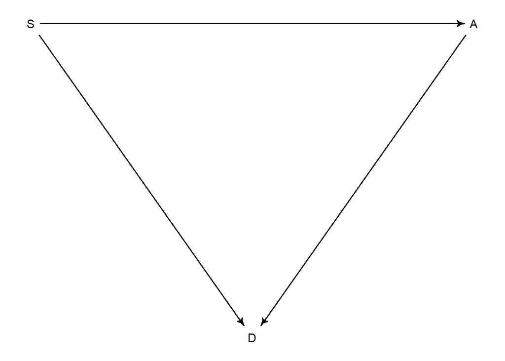

```r
dag5H4.5 <- dagitty('dag{ D <- S -> A -> D}')
coordinates(dag5H4.5) <- list(x=c(S=0, D=1, A=2), y=c(S=0, D=1, A=0))
drawdag(dag5H4.5)
```

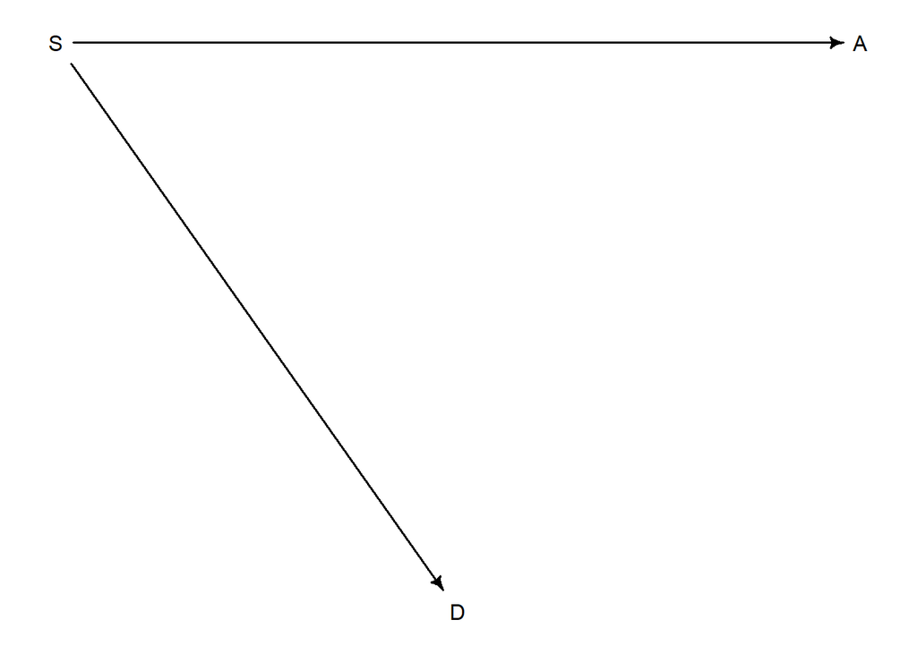

```r
impliedConditionalIndependencies(dag5H4.5)

dag5H4.6 <- dagitty('dag{ D <- S -> A}')
coordinates(dag5H4.6) <- list(x=c(S=0, D=1, A=2), y=c(S=0, D=1, A=0))
drawdag(dag5H4.6)
```

```r
impliedConditionalIndependencies(dag5H4.6)
```

```
## A _||_ D | S
```

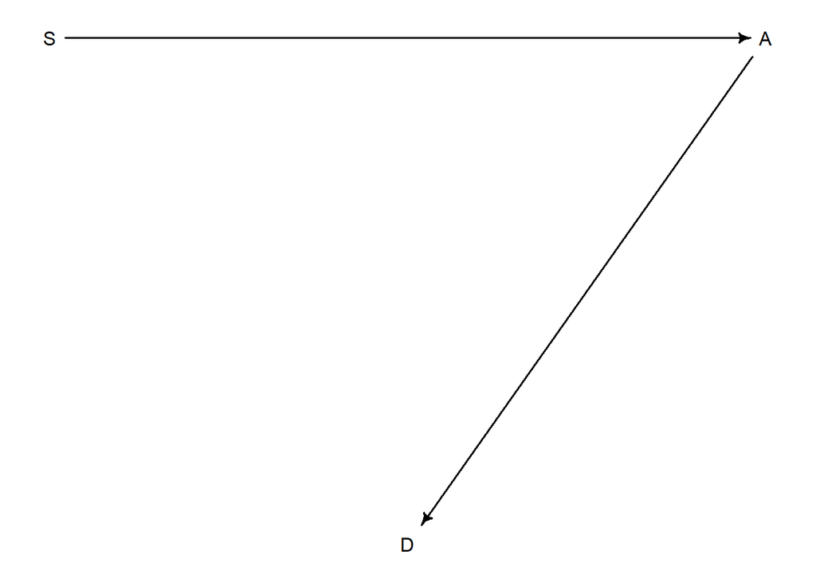

```r
dag5H4.7 <- dagitty('dag{ S -> A -> D}')
coordinates(dag5H4.7) <- list(x=c(S=0, D=1, A=2), y=c(S=0, D=1, A=0))
drawdag(dag5H4.7)
```

```r
impliedConditionalIndependencies(dag5H4.7)
```

```
## D _||_ S | A
```

To distinguish these DAGs, we need to compare again a multiple regression (`D` on `A` and `S`) to both single-predictor cases (our model `m5.5H4` is McElreath’s `m5.1`):

```r
m5.5H4 <-
  brm(data = d,
      family = gaussian(link = "identity"),
      D ~ 1 + A,
      prior = c(prior(normal(0, 2.5), class = Intercept),
                prior(normal(0, 2.5), class = b),
                prior(exponential(1), class = sigma)),
      iter = 5e3
  )

m6.5H4 <-
  brm(data = d,
      family = gaussian(link = "identity"),
      D ~ 0 + S,
      prior = c(prior(normal(0, 2.5), class = b),
                prior(exponential(1), class = sigma)),
      iter = 5e3
  )

m7.5H4 <-
  brm(data = d,
      family = gaussian(link = "identity"),
      D ~ 0 + S + A,
      prior = c(prior(normal(0, 2.5), class = b),
                prior(exponential(1), class = sigma)),
      iter = 5e3
  )
```

```r
summary(m5.5H4)
```

```
##  Family: gaussian
##   Links: mu = identity; sigma = identity
## Formula: D ~ 1 + A
##    Data: d (Number of observations: 50)
## Samples: 4 chains, each with iter = 5000; warmup = 2500; thin = 1;
##          total post-warmup samples = 10000
##
## Population-Level Effects:
##           Estimate Est.Error l-95% CI u-95% CI Rhat Bulk_ESS Tail_ESS
## Intercept     0.00      0.12    -0.23     0.23 1.00     8570     6876
## A            -0.59      0.12    -0.83    -0.36 1.00     9431     7545
##
## Family Specific Parameters:
##       Estimate Est.Error l-95% CI u-95% CI Rhat Bulk_ESS Tail_ESS
## sigma     0.83      0.09     0.67     1.01 1.00     8671     7042
##
## Samples were drawn using sampling(NUTS). For each parameter, Bulk_ESS
## and Tail_ESS are effective sample size measures, and Rhat is the potential
## scale reduction factor on split chains (at convergence, Rhat = 1).
```

```r
summary(m6.5H4)
```

```
##  Family: gaussian
##   Links: mu = identity; sigma = identity
## Formula: D ~ 0 + S
##    Data: d (Number of observations: 50)
## Samples: 4 chains, each with iter = 5000; warmup = 2500; thin = 1;
##          total post-warmup samples = 10000
##
## Population-Level Effects:
##    Estimate Est.Error l-95% CI u-95% CI Rhat Bulk_ESS Tail_ESS
## S0    -0.21      0.16    -0.52     0.11 1.00     9377     7094
## S1     0.54      0.26     0.02     1.05 1.00     9230     7272
##
## Family Specific Parameters:
##       Estimate Est.Error l-95% CI u-95% CI Rhat Bulk_ESS Tail_ESS
## sigma     0.96      0.10     0.79     1.18 1.00     9720     8089
##
## Samples were drawn using sampling(NUTS). For each parameter, Bulk_ESS
## and Tail_ESS are effective sample size measures, and Rhat is the potential
## scale reduction factor on split chains (at convergence, Rhat = 1).
```

```r
summary(m7.5H4)
```

```
##  Family: gaussian
##   Links: mu = identity; sigma = identity
## Formula: D ~ 0 + S + A
##    Data: d (Number of observations: 50)
## Samples: 4 chains, each with iter = 5000; warmup = 2500; thin = 1;
##          total post-warmup samples = 10000
##
## Population-Level Effects:
##    Estimate Est.Error l-95% CI u-95% CI Rhat Bulk_ESS Tail_ESS
## S0    -0.13      0.14    -0.39     0.14 1.00    10460     8078
## S1     0.33      0.22    -0.10     0.76 1.00     9342     7669
## A     -0.54      0.12    -0.78    -0.31 1.00     9866     7358
##
## Family Specific Parameters:
##       Estimate Est.Error l-95% CI u-95% CI Rhat Bulk_ESS Tail_ESS
## sigma     0.81      0.09     0.66     1.00 1.00     8704     7138
##
## Samples were drawn using sampling(NUTS). For each parameter, Bulk_ESS
## and Tail_ESS are effective sample size measures, and Rhat is the potential
## scale reduction factor on split chains (at convergence, Rhat = 1).
```

Since conditioning on `S` and `A`, respectively, doesn’t make the respective other effect vanish, I’m going with DAG `dag5H4.5`: “southernness” (`S`) increases the divorce rate (`D`) as well as decreasing median age at marriage (`A`). The lower the median age at marriage, the higher the divorce rate; controlling for “southernness” slightly decreases the magnitude of this effect.